# predict_status

Bernice Cheung

8/24/2021

Import all data

```r
merged_progress_w <- read.csv(here("TimeSeries", "Inputs", "merged_progress_clean_w.csv"))

factorScore_4f <- read.csv(here("Baseline", "Outputs", "factorScoreDf_4f.csv"))
factorScore_6f <- read.csv(here("Baseline", "Outputs", "factorScoreDf_6f.csv"))

baseline_goalRep <- read.csv(here("Baseline", "Outputs", "baseline_goalRap.csv"))

factorScore_4f_post <- read.csv(here("TimeSeries", "Inputs", "factorScoreDf_4f_post.csv"))
factorScore_6f_post <- read.csv(here("TimeSeries", "Inputs", "factorScoreDf_6f_post.csv"))
```

# Descriptives on the final status

A bar plot of the final status by time and goal type

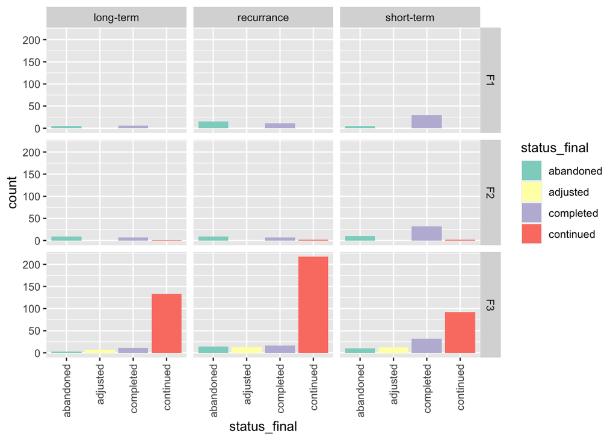

```r
merged_progress_w %>%
  filter(is.na(final_time) == F) %>%
  ggplot(aes(status_final)) +
  geom_bar(aes(fill = status_final)) +
  scale_fill_brewer(palette="Set3") +
  facet_grid(final_time~goalType) +
  theme(axis.text.x = element_text(angle = 90, vjust = 0.5, hjust=1))
```

Violin plots for each baseline factor scores by final status (4-factor)

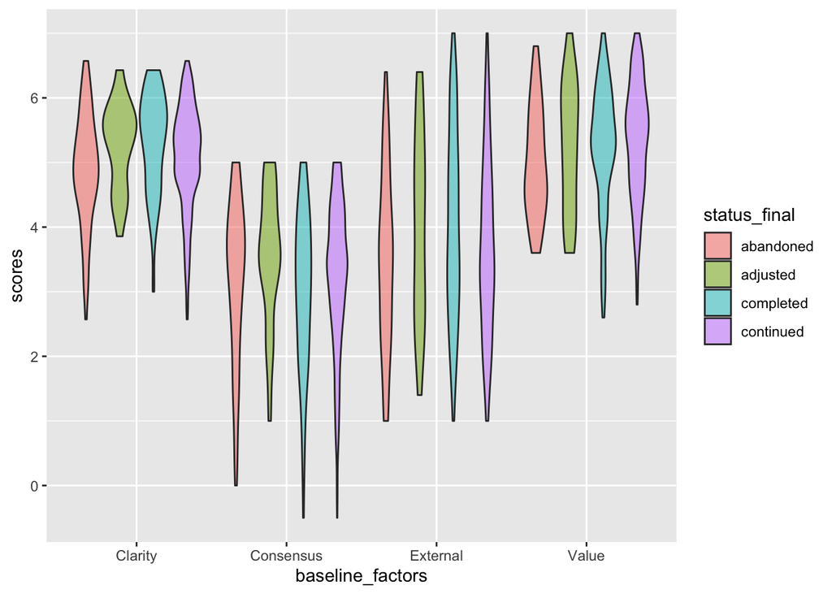

```r
merged_progress_w %>%
  filter(is.na(status_final) == F) %>%
  select(-goalType) %>%
  left_join(factorScore_4f, by = c("MTurkCode", "goal")) %>%
  gather(Value : Consensus, key = "baseline_factors", value = "scores") %>%
  ggplot(aes(fill = status_final, y = scores, x = baseline_factors)) +
  geom_violin(position="dodge", alpha=0.5, outlier.colour="transparent")
```

Violin plots for each baseline factor scores by final status (6-factor)

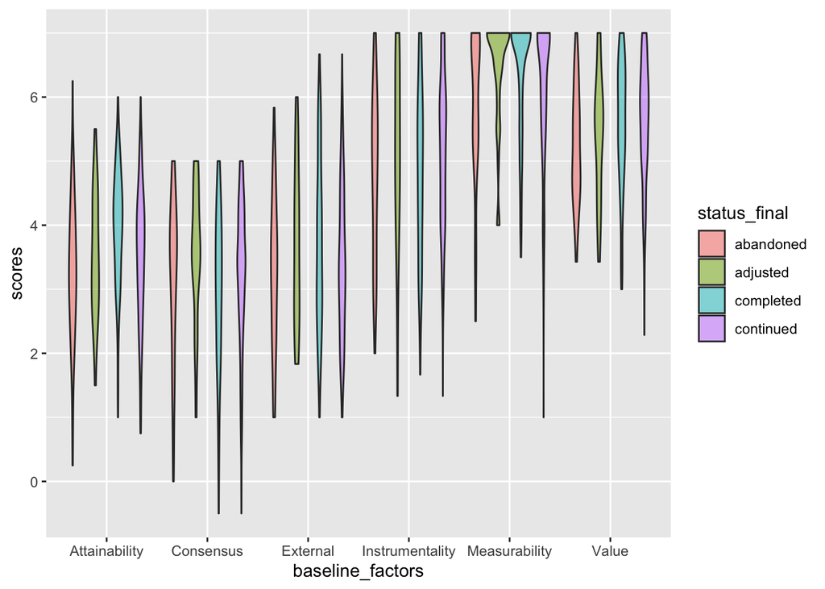

```r
merged_progress_w %>%
  filter(is.na(status_final) == F) %>%
  select(-goalType) %>%
  left_join(factorScore_6f, by = c("MTurkCode", "goal")) %>%
  gather(Value : Instrumentality, key = "baseline_factors", value = "scores") %>%
  ggplot(aes(fill = status_final, y = scores, x = baseline_factors)) +
  geom_violin(position="dodge", alpha=0.5, outlier.colour="transparent")
```

Violin plots for each final factor scores by final status (4-factor)

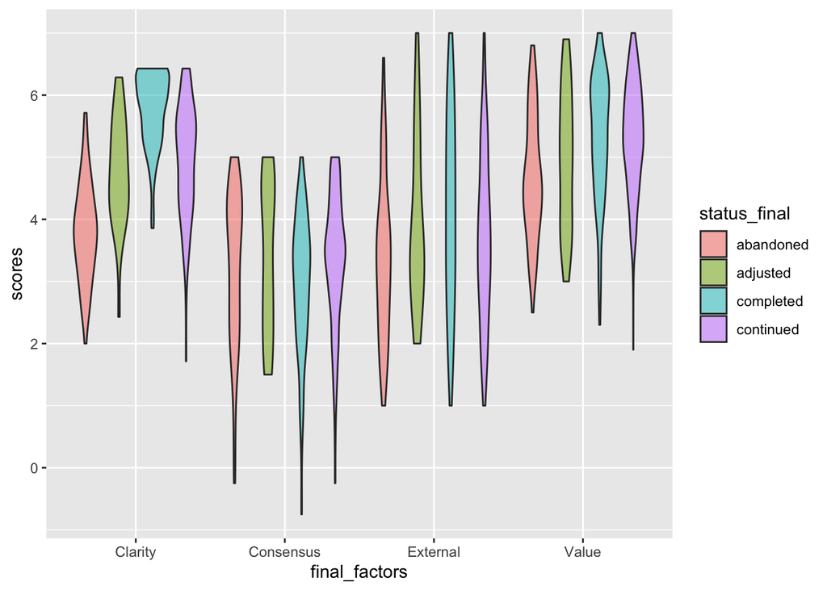

```r
merged_progress_w %>%
  filter(is.na(status_final) == F) %>%
  select(-goalType) %>%
  left_join(factorScore_4f_post, by = c("MTurkCode", "goal")) %>%
  gather(Value : Consensus, key = "final_factors", value = "scores") %>%
  ggplot(aes(fill = status_final, y = scores, x = final_factors)) +
  geom_violin(position="dodge", alpha=0.5, outlier.colour="transparent")
```

Violin plots for each final factor scores by final status (6-factor)

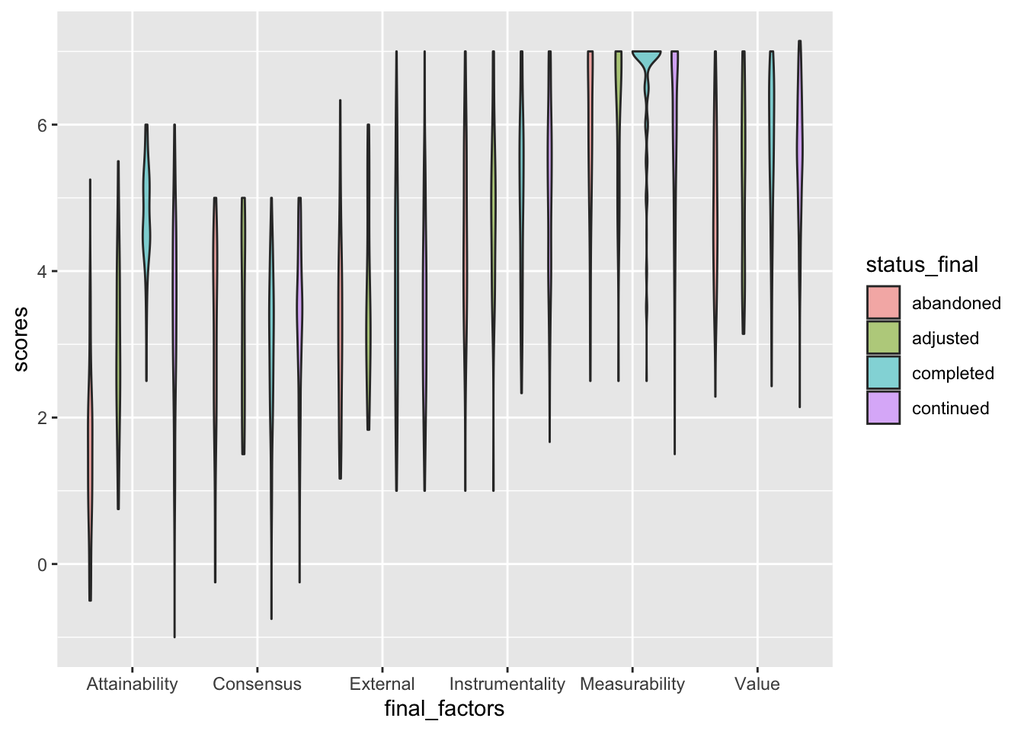

```r
merged_progress_w %>%
  filter(is.na(status_final) == F) %>%
  select(-goalType) %>%
  left_join(factorScore_6f_post, by = c("MTurkCode", "goal")) %>%
  gather(Value : Instrumentality, key = "final_factors", value = "scores") %>%
  ggplot(aes(fill = status_final, y = scores, x = final_factors)) +
  geom_violin(position="dodge", alpha=0.5, outlier.colour="transparent")
```

## Notes on the descriptives:

The numbers of cases within each groups are very uneven, so the interpretation of the models will be very tricky. From the violin plots, we can see that the factor clarity / attainability show the most variation across the final statuses (consistent with the progress models). We can also see that among the other factors, adjusted goals show some different patterns than the three other types of goals. I’m not sure what would be the best way to deal with these adjusted goals. The count table for hte final status is listed below. We only have 32 goals that were adjusted at their final follow-up but in total 80 goals have been adjusted through out the period. Due to the very small N, the violin plot can be very misleading. To simplify the analysis at this moment, I excluded all the 80 goals that have been adjusted at any given follow-up. I wish we could get more adjusted goals because it would be interesting to see what types of goals were adjusted vs. abandoned.

```r
table(merged_progress_w$status_final)
```

```
##
## abandoned  adjusted completed continued
##        80        32       152       447
```

# Multinomial logistic regression models for final status

## clean datasets

### exclude adjusted goals

80 goals were excluded

```r
# exclude goals that were adjsuted at any given time
merged_progress_w_adjust <- merged_progress_w %>%
  rowwise() %>%
  mutate(adjust_num = sum(c_across(starts_with("status_F")) == "adjusted", na.rm = T)) %>%
  filter(adjust_num > 0)

merged_progress_w_clean <- merged_progress_w %>%
  anti_join(merged_progress_w_adjust, by = c("MTurkCode", "goal"))

#write.csv(merged_progress_w_adjust, "../inputs/merged_progress_w_adjust.csv", row.names = F)
#write.csv(merged_progress_w_clean, "../inputs/merged_progress_w_no_adj.csv", row.names = F)
```

### set the reference group

Make the continued goal (with the largest N) as the reference level of the final status; recurrence (with the largest N) as the reference level of the goal type; and F3 as the reference level of the final time.

```r
merged_progress_w_clean$status_final <- as.factor(merged_progress_w_clean$status_final)
merged_progress_w_clean$status_final <- relevel(merged_progress_w_clean$status_final, ref = "continued")

merged_progress_w_clean$goalType <- as.factor(merged_progress_w_clean$goalType)
merged_progress_w_clean$goalType <- relevel(merged_progress_w_clean$goalType, ref = "recurrance")

merged_progress_w_clean$final_time <- as.factor(merged_progress_w_clean$final_time)
merged_progress_w_clean$final_time <- relevel(merged_progress_w_clean$final_time, ref = "F3")
```

### exclude rows with missing data across IVs

To ensure that all models have the same N, we only included complete cases across all IVs. 136 rows were excluded. In total, 606 goals were included in the following analysis.

```r
merged_4f_base_clean <- merged_progress_w_clean %>%
  left_join(select(factorScore_4f, - goalType), by = c("MTurkCode", "goal")) %>%
  drop_na(goalType, final_time, progress_base, Clarity, Value, External, Consensus)

merged_6f_base_clean <- merged_progress_w_clean %>%
  left_join(select(factorScore_6f, - goalType), by = c("MTurkCode", "goal")) %>%
  drop_na(goalType, final_time, progress_base, Attainability, Measurability, Value, External, Consensus, Instrumentality)
```

### count table by groups

```r
tabyl(merged_4f_base_clean, goalType, status_final, final_time)
```

```
## $F2
##    goalType continued abandoned completed
##  recurrance         2         6         7
##   long-term         1         7         6
##  short-term         2        10        31
##
## $F3
##    goalType continued abandoned completed
##  recurrance       191        11        14
##   long-term       120         3        10
##  short-term        78         8        30
##
## $F1
##    goalType continued abandoned completed
##  recurrance         0        13        11
##   long-term         0         5         6
##  short-term         0         5        29
```

## Model 1 (no baseline factor scores)

model 1: using the goal type, the final time and the baseline progress as the predictors

```r
# create a model
m1 <- multinom(status_final ~ goalType + final_time + scale(progress_base), data = merged_4f_base_clean)
```

A summary of the model1

```r
summary(m1)
```

```
## Call:
## multinom(formula = status_final ~ goalType + final_time + scale(progress_base),
##     data = merged_4f_base_clean)
##
## Coefficients:
##           (Intercept) goalTypelong-term goalTypeshort-term final_timeF1
## abandoned   -2.834768      -0.563117821          0.1705144     12.67824
## completed   -2.606893       0.006274567          1.6797833     12.31991
##           final_timeF2 scale(progress_base)
## abandoned     4.386414        -0.4287095577
## completed     3.919597        -0.0001709347
##
## Std. Errors:
##           (Intercept) goalTypelong-term goalTypeshort-term final_timeF1
## abandoned   0.2812822         0.4420463          0.3922018     26.59536
## completed   0.2557474         0.3918828          0.3214495     26.59455
##           final_timeF2 scale(progress_base)
## abandoned    0.5481029            0.1848342
## completed    0.5086239            0.1442405
##
## Residual Deviance: 663.6579
## AIC: 687.6579
```

use a 2-tailed z test to look at the p value of each level of IV

```r
m1_z <- summary(m1)$coefficients/summary(m1)$standard.errors
m1_p <- (1 - pnorm(abs(m1_z), 0, 1)) * 2
m1_p
```

```
##           (Intercept) goalTypelong-term goalTypeshort-term final_timeF1
## abandoned           0         0.2027028       6.637353e-01    0.6335696
## completed           0         0.9872253       1.735418e-07    0.6431857
##           final_timeF2 scale(progress_base)
## abandoned 1.110223e-15           0.02037185
## completed 1.287859e-14           0.99905445
```

## Models with the baseline 4-factor scores

### Model 2 (include baseline Clarity)

model 2: Adding baseline clarity factor score to model 1

```r
# create a model
m2 <- multinom(status_final ~ goalType + final_time + scale(progress_base) + scale(Clarity), data = merged_4f_base_clean)
```

A summary of the model 2

```r
summary(m2)
```

```
## Call:
## multinom(formula = status_final ~ goalType + final_time + scale(progress_base) +
##     scale(Clarity), data = merged_4f_base_clean)
##
## Coefficients:
##           (Intercept) goalTypelong-term goalTypeshort-term final_timeF1
## abandoned   -2.825976       -0.60139085          0.1891364     12.72455
## completed   -2.675449        0.08251883          1.6300315     12.46859
##           final_timeF2 scale(progress_base) scale(Clarity)
## abandoned     4.348168           -0.3795373     -0.1101497
## completed     4.044470           -0.0387988      0.3918268
##
## Std. Errors:
##           (Intercept) goalTypelong-term goalTypeshort-term final_timeF1
## abandoned   0.2805878         0.4477637          0.3958538     28.01223
## completed   0.2625593         0.3941404          0.3252765     28.01159
##           final_timeF2 scale(progress_base) scale(Clarity)
## abandoned    0.5495546            0.1856593      0.1675522
## completed    0.5156837            0.1441096      0.1517728
##
## Residual Deviance: 651.4397
## AIC: 679.4397
```

Plot the predicted probabilities of the clarity factor across goal types at F3 when holding the baseline progress at its mean.

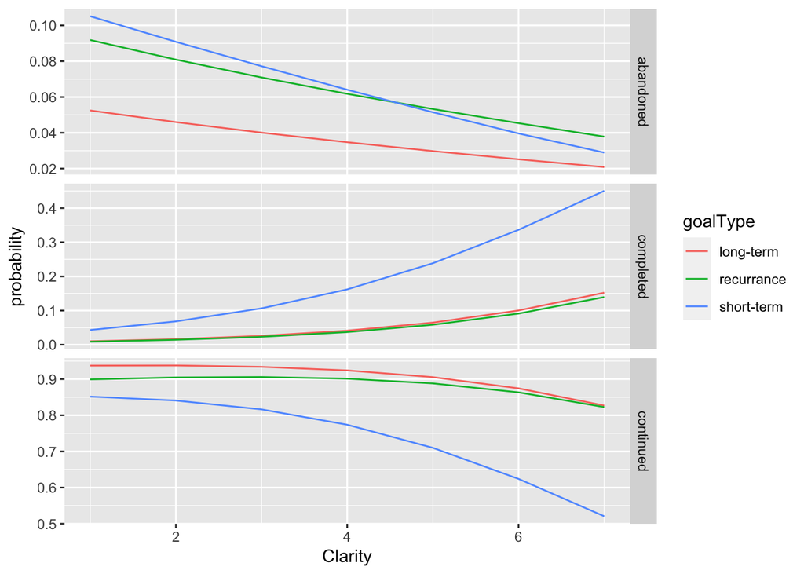

```r
# Generate the predicted probabilities
m2_clarity <- data.frame(goalType = c("short-term", "recurrance", "long-term"), Clarity = rep(c(1:7), 3), final_time = "F3", progress_base = mean(merged_4f_base_clean$progress_base))

# generate the pp dataframe
m2_pp <- cbind(m2_clarity, predict(m2, newdata = m2_clarity, type = "probs", se = TRUE))

# transform to long format and plot the probability across goal types
m2_pp %>%
  gather(continued: completed, key = "final_status", value = "probability") %>%
  ggplot(aes(x = Clarity, y = probability, colour = goalType)) +
  geom_line() +
  facet_grid(final_status ~ ., scales = "free")
```

From this plot, we can tell that the effect of clarity is the strongest among short-term goals. As the clarity increase, the probability of completing the goals goes up and the probability of continuing the goals goes down. Because short-term goals are the goals that should be completed at F3, and final status “continued” can also be interpreted as haven’t completed on time.

### A comparison between model 1 & 2

The anova test showed that the chi-square is 12.22 and the p = .002, so including the baseline clarity factor score improves the model fit.

```r
anova(m1,m2) %>%
  kable(format = "html", escape = F) %>%
  kable_styling(bootstrap_options = c("striped", "hover", "condensed"), full_width = F,position = "center")
```

| Model | Resid. df | Resid. Dev | Test | Df | LR stat. | Pr(Chi) |
| --- | --- | --- | --- | --- | --- | --- |
| goalType + final_time + scale(progress_base) | 1200 | 663.6579 |  | NA | NA | NA |
| goalType + final_time + scale(progress_base) + scale(Clarity) | 1198 | 651.4397 | 1 vs 2 | 2 | 12.21821 | 0.0022225 |

### model 3 (include baseline Clarity + Value)

```r
# create a model
m3 <- multinom(status_final ~ goalType + final_time + scale(progress_base) + scale(Clarity) + scale(Value),data = merged_4f_base_clean)
summary(m3)
```

```
## Call:
## multinom(formula = status_final ~ goalType + final_time + scale(progress_base) +
##     scale(Clarity) + scale(Value), data = merged_4f_base_clean)
##
## Coefficients:
##           (Intercept) goalTypelong-term goalTypeshort-term final_timeF1
## abandoned   -2.871496        -0.5521102          0.1073621     14.72764
## completed   -2.684027         0.1118124          1.6428220     14.43213
##           final_timeF2 scale(progress_base) scale(Clarity) scale(Value)
## abandoned     4.324275          -0.40312739   -0.007886372   -0.4563882
## completed     4.024813          -0.03215332    0.416086732   -0.1651277
##
## Std. Errors:
##           (Intercept) goalTypelong-term goalTypeshort-term final_timeF1
## abandoned   0.2852749         0.4513616          0.4037374     73.96781
## completed   0.2642877         0.3977234          0.3280017     73.96751
##           final_timeF2 scale(progress_base) scale(Clarity) scale(Value)
## abandoned    0.5538044            0.1870940      0.1745640    0.1693094
## completed    0.5160659            0.1446048      0.1561049    0.1408315
##
## Residual Deviance: 644.2143
## AIC: 676.2143
```

### A comparison between model 2 & 3

```r
anova(m2,m3) %>%
  kable(format = "html", escape = F) %>%
  kable_styling(bootstrap_options = c("striped", "hover", "condensed"), full_width = F,position = "center")
```

| Model | Resid. df | Resid. Dev | Test | Df | LR stat. | Pr(Chi) |
| --- | --- | --- | --- | --- | --- | --- |
| goalType + final_time + scale(progress_base) + scale(Clarity) | 1198 | 651.4397 |  | NA | NA | NA |
| goalType + final_time + scale(progress_base) + scale(Clarity) + scale(Value) | 1196 | 644.2143 | 1 vs 2 | 2 | 7.225446 | 0.0269783 |

### model 4 (include baseline Clarity + Value + Consensus)

```r
# create a model
m4 <- multinom(status_final ~ goalType + final_time + scale(progress_base) + scale(Clarity) + scale(Value) + Consensus,data = merged_4f_base_clean)
summary(m4)
```

```
## Call:
## multinom(formula = status_final ~ goalType + final_time + scale(progress_base) +
##     scale(Clarity) + scale(Value) + Consensus, data = merged_4f_base_clean)
##
## Coefficients:
##           (Intercept) goalTypelong-term goalTypeshort-term final_timeF1
## abandoned   -3.605208        -0.5330943          0.1398051     16.59851
## completed   -2.522494         0.1124961          1.6352673     16.23622
##           final_timeF2 scale(progress_base) scale(Clarity) scale(Value)
## abandoned     4.327127          -0.37811962    -0.00392544   -0.5691742
## completed     4.022676          -0.03992206     0.40716419   -0.1394265
##             Consensus
## abandoned  0.21121235
## completed -0.04877515
##
## Std. Errors:
##           (Intercept) goalTypelong-term goalTypeshort-term final_timeF1
## abandoned   0.6393843         0.4543106          0.4058612    0.2038827
## completed   0.4840097         0.3980206          0.3291521    0.2038831
##           final_timeF2 scale(progress_base) scale(Clarity) scale(Value)
## abandoned    0.5554360            0.1869937      0.1747706    0.1870421
## completed    0.5158977            0.1450591      0.1563023    0.1458297
##           Consensus
## abandoned 0.1612636
## completed 0.1239067
##
## Residual Deviance: 641.3026
## AIC: 677.3026
```

### A comparison between model 3 & 4

The anova test showed that the chi-square is 2.91 and the p = .23, so adding the baseline consensus factor score doesn’t improve the model fit.

```r
anova(m3,m4) %>%
  kable(format = "html", escape = F) %>%
  kable_styling(bootstrap_options = c("striped", "hover", "condensed"), full_width = F,position = "center")
```

| Model | Resid. df | Resid. Dev | Test | Df | LR stat. | Pr(Chi) |
| --- | --- | --- | --- | --- | --- | --- |
| goalType + final_time + scale(progress_base) + scale(Clarity) + scale(Value) | 1196 | 644.2143 |  | NA | NA | NA |
| goalType + final_time + scale(progress_base) + scale(Clarity) + scale(Value) + Consensus | 1194 | 641.3026 | 1 vs 2 | 2 | 2.911731 | 0.2331984 |

### model 5 (including baseline clarity, value and external)

```r
# create a model
m5 <- multinom(status_final ~ goalType + final_time + scale(progress_base) + scale(Clarity) + scale(Value) + scale(External),data = merged_4f_base_clean)
summary(m5)
```

```
## Call:
## multinom(formula = status_final ~ goalType + final_time + scale(progress_base) +
##     scale(Clarity) + scale(Value) + scale(External), data = merged_4f_base_clean)
##
## Coefficients:
##           (Intercept) goalTypelong-term goalTypeshort-term final_timeF1
## abandoned   -2.884156       -0.53388033          0.1358241     16.01656
## completed   -2.682856        0.09280447          1.6188022     15.70224
##           final_timeF2 scale(progress_base) scale(Clarity) scale(Value)
## abandoned     4.327608          -0.37903680    -0.02721905   -0.4206619
## completed     4.010069          -0.04705966     0.44856873   -0.2487194
##           scale(External)
## abandoned     -0.06828488
## completed      0.20437741
##
## Std. Errors:
##           (Intercept) goalTypelong-term goalTypeshort-term final_timeF1
## abandoned   0.2877162         0.4525958          0.4066240     141.8573
## completed   0.2655539         0.3988547          0.3295332     141.8572
##           final_timeF2 scale(progress_base) scale(Clarity) scale(Value)
## abandoned    0.5544763            0.1887245      0.1766038    0.1880751
## completed    0.5166512            0.1455203      0.1573126    0.1536772
##           scale(External)
## abandoned       0.1893152
## completed       0.1476469
##
## Residual Deviance: 640.9562
## AIC: 676.9562
```

### A comparison between model 3 & 5

The anova test showed that the chi-square is 3.26 and the p = .20, so adding the baseline external factor score doesn’t improve the model fit.

```r
anova(m3,m5) %>%
  kable(format = "html", escape = F) %>%
  kable_styling(bootstrap_options = c("striped", "hover", "condensed"), full_width = F,position = "center")
```

| Model | Resid. df | Resid. Dev | Test | Df | LR stat. | Pr(Chi) |
| --- | --- | --- | --- | --- | --- | --- |
| goalType + final_time + scale(progress_base) + scale(Clarity) + scale(Value) | 1196 | 644.2143 |  | NA | NA | NA |
| goalType + final_time + scale(progress_base) + scale(Clarity) + scale(Value) + scale(External) | 1194 | 640.9562 | 1 vs 2 | 2 | 3.258132 | 0.1961127 |

### The final model that inlcudes the baseline factor scores

After model comparisons, model 3 (including both the baseline clarity and value) fit the best.

## Models with the baseline 6-factor scores

### Model 6 (include baseline Attainability)

model 6: Adding baseline attainability factor score to model 1

```r
# create a model
m6 <- multinom(status_final ~ goalType + final_time + scale(progress_base) + scale(Attainability), data = merged_6f_base_clean)
```

```r
summary(m6)
```

```
## Call:
## multinom(formula = status_final ~ goalType + final_time + scale(progress_base) +
##     scale(Attainability), data = merged_6f_base_clean)
##
## Coefficients:
##           (Intercept) goalTypelong-term goalTypeshort-term final_timeF1
## abandoned   -2.873322       -0.58753321          0.2904164     13.88934
## completed   -2.640059        0.07876844          1.6053062     13.55906
##           final_timeF2 scale(progress_base) scale(Attainability)
## abandoned     4.354196           -0.3498373           -0.1862779
## completed     3.990966           -0.0710446            0.3611342
##
## Std. Errors:
##           (Intercept) goalTypelong-term goalTypeshort-term final_timeF1
## abandoned   0.2855086         0.4494689          0.3965661     49.97673
## completed   0.2586690         0.3940369          0.3239612     49.97633
##           final_timeF2 scale(progress_base) scale(Attainability)
## abandoned    0.5485604            0.1896232            0.1745596
## completed    0.5145601            0.1457624            0.1500592
##
## Residual Deviance: 651.1724
## AIC: 679.1724
```

### A comparison between model 1 & 6

The anova test showed that the chi-square is 12.48 and the p = .002, so including the baseline attainability factor score improves the model fit.

```r
anova(m1,m6) %>%
  kable(format = "html", escape = F) %>%
  kable_styling(bootstrap_options = c("striped", "hover", "condensed"), full_width = F,position = "center")
```

| Model | Resid. df | Resid. Dev | Test | Df | LR stat. | Pr(Chi) |
| --- | --- | --- | --- | --- | --- | --- |
| goalType + final_time + scale(progress_base) | 1200 | 663.6579 |  | NA | NA | NA |
| goalType + final_time + scale(progress_base) + scale(Attainability) | 1198 | 651.1724 | 1 vs 2 | 2 | 12.48553 | 0.0019445 |

### model 7 (include baseline Attainability + Measurability)

```r
# create a model
m7 <- multinom(status_final ~ goalType + final_time + scale(progress_base) + scale(Attainability) + scale(Measurability),data = merged_6f_base_clean)
summary(m7)
```

```
## Call:
## multinom(formula = status_final ~ goalType + final_time + scale(progress_base) +
##     scale(Attainability) + scale(Measurability), data = merged_6f_base_clean)
##
## Coefficients:
##           (Intercept) goalTypelong-term goalTypeshort-term final_timeF1
## abandoned   -2.849513        -0.6225636          0.2481017     14.99422
## completed   -2.678336         0.0940000          1.5646414     14.75356
##           final_timeF2 scale(progress_base) scale(Attainability)
## abandoned     4.340963          -0.33275369           -0.1798291
## completed     4.033084          -0.06726987            0.2894210
##           scale(Measurability)
## abandoned          -0.03741656
## completed           0.29588026
##
## Std. Errors:
##           (Intercept) goalTypelong-term goalTypeshort-term final_timeF1
## abandoned   0.2841901         0.4514452          0.4004353     87.52903
## completed   0.2642140         0.3955510          0.3272611     87.52883
##           final_timeF2 scale(progress_base) scale(Attainability)
## abandoned    0.5486864             0.189309            0.1835554
## completed    0.5152337             0.145745            0.1578168
##           scale(Measurability)
## abandoned            0.1723134
## completed            0.1750430
##
## Residual Deviance: 646.5502
## AIC: 678.5502
```

### A comparison between model 6 & 7

The anova test showed that the chi-square is 4.62 and the p = .1, so including the baseline measurability factor score doesn’t improve the model fit.

```r
anova(m6,m7) %>%
  kable(format = "html", escape = F) %>%
  kable_styling(bootstrap_options = c("striped", "hover", "condensed"), full_width = F,position = "center")
```

| Model | Resid. df | Resid. Dev | Test | Df | LR stat. | Pr(Chi) |
| --- | --- | --- | --- | --- | --- | --- |
| goalType + final_time + scale(progress_base) + scale(Attainability) | 1198 | 651.1724 |  | NA | NA | NA |
| goalType + final_time + scale(progress_base) + scale(Attainability) + scale(Measurability) | 1196 | 646.5502 | 1 vs 2 | 2 | 4.622184 | 0.0991529 |

### model 8 (include baseline Attainability + Value)

```r
# create a model
m8 <- multinom(status_final ~ goalType + final_time + scale(progress_base) + scale(Attainability) + scale(Value) ,data = merged_6f_base_clean)
summary(m8)
```

```
## Call:
## multinom(formula = status_final ~ goalType + final_time + scale(progress_base) +
##     scale(Attainability) + scale(Value), data = merged_6f_base_clean)
##
## Coefficients:
##           (Intercept) goalTypelong-term goalTypeshort-term final_timeF1
## abandoned   -2.925910       -0.54713923           0.235449     14.87475
## completed   -2.659276        0.09567027           1.638649     14.51052
##           final_timeF2 scale(progress_base) scale(Attainability) scale(Value)
## abandoned     4.296826           -0.3741991           -0.1277146  -0.40838069
## completed     3.983127           -0.0661968            0.3571459  -0.00439024
##
## Std. Errors:
##           (Intercept) goalTypelong-term goalTypeshort-term final_timeF1
## abandoned   0.2899399         0.4544452          0.4024308     79.80183
## completed   0.2609438         0.3973791          0.3257144     79.80154
##           final_timeF2 scale(progress_base) scale(Attainability) scale(Value)
## abandoned    0.5526547            0.1904732            0.1765310    0.1640790
## completed    0.5150871            0.1459076            0.1509334    0.1397128
##
## Residual Deviance: 643.5651
## AIC: 675.5651
```

### A comparison between model 6 & 8

The anova test showed that the chi-square is 7.61 and the p = .02, so adding the baseline value factor score improves the model fit.

```r
anova(m6,m8) %>%
  kable(format = "html", escape = F) %>%
  kable_styling(bootstrap_options = c("striped", "hover", "condensed"), full_width = F,position = "center")
```

| Model | Resid. df | Resid. Dev | Test | Df | LR stat. | Pr(Chi) |
| --- | --- | --- | --- | --- | --- | --- |
| goalType + final_time + scale(progress_base) + scale(Attainability) | 1198 | 651.1724 |  | NA | NA | NA |
| goalType + final_time + scale(progress_base) + scale(Attainability) + scale(Value) | 1196 | 643.5651 | 1 vs 2 | 2 | 7.607329 | 0.0222889 |

### model 9 (including baseline Attainability, Value, External)

```r
# create a model
m9 <- multinom(status_final ~ goalType + final_time + scale(progress_base) + scale(Attainability) + scale(Value) + scale(External),data = merged_6f_base_clean)
summary(m9)
```

```
## Call:
## multinom(formula = status_final ~ goalType + final_time + scale(progress_base) +
##     scale(Attainability) + scale(Value) + scale(External), data = merged_6f_base_clean)
##
## Coefficients:
##           (Intercept) goalTypelong-term goalTypeshort-term final_timeF1
## abandoned   -2.955936       -0.51493958          0.2765216     15.97726
## completed   -2.654451        0.07432401          1.6196230     15.58543
##           final_timeF2 scale(progress_base) scale(Attainability) scale(Value)
## abandoned     4.312396          -0.33331003           -0.1640354   -0.3547874
## completed     3.971914          -0.08209807            0.3794544   -0.0409962
##           scale(External)
## abandoned      -0.1388000
## completed       0.1110358
##
## Std. Errors:
##           (Intercept) goalTypelong-term goalTypeshort-term final_timeF1
## abandoned   0.2940019         0.4550369          0.4055490     137.5387
## completed   0.2613510         0.3986008          0.3266158     137.5385
##           final_timeF2 scale(progress_base) scale(Attainability) scale(Value)
## abandoned    0.5544211            0.1928807            0.1796203    0.1757272
## completed    0.5154492            0.1468013            0.1519133    0.1475306
##           scale(External)
## abandoned       0.1847092
## completed       0.1444929
##
## Residual Deviance: 641.3673
## AIC: 677.3673
```

### A comparison between model 8 & 9

The anova test showed that the chi-square is 2.20 and the p = .33, so adding the baseline external factor score doesn’t improve the model fit.

```r
anova(m8,m9) %>%
  kable(format = "html", escape = F) %>%
  kable_styling(bootstrap_options = c("striped", "hover", "condensed"), full_width = F,position = "center")
```

| Model | Resid. df | Resid. Dev | Test | Df | LR stat. | Pr(Chi) |
| --- | --- | --- | --- | --- | --- | --- |
| goalType + final_time + scale(progress_base) + scale(Attainability) + scale(Value) | 1196 | 643.5651 |  | NA | NA | NA |
| goalType + final_time + scale(progress_base) + scale(Attainability) + scale(Value) + scale(External) | 1194 | 641.3673 | 1 vs 2 | 2 | 2.197835 | 0.3332317 |

### The final model that includes the basleine 6-factor scores

After model comparisons, model 8 (including baseline attainability and value) has the best model fit.

## Interpretations of the final models:

### model 3 (Clarity + Value from the 4-factor model)

A summary of the model

```r
summary(m3)
```

```
## Call:
## multinom(formula = status_final ~ goalType + final_time + scale(progress_base) +
##     scale(Clarity) + scale(Value), data = merged_4f_base_clean)
##
## Coefficients:
##           (Intercept) goalTypelong-term goalTypeshort-term final_timeF1
## abandoned   -2.871496        -0.5521102          0.1073621     14.72764
## completed   -2.684027         0.1118124          1.6428220     14.43213
##           final_timeF2 scale(progress_base) scale(Clarity) scale(Value)
## abandoned     4.324275          -0.40312739   -0.007886372   -0.4563882
## completed     4.024813          -0.03215332    0.416086732   -0.1651277
##
## Std. Errors:
##           (Intercept) goalTypelong-term goalTypeshort-term final_timeF1
## abandoned   0.2852749         0.4513616          0.4037374     73.96781
## completed   0.2642877         0.3977234          0.3280017     73.96751
##           final_timeF2 scale(progress_base) scale(Clarity) scale(Value)
## abandoned    0.5538044            0.1870940      0.1745640    0.1693094
## completed    0.5160659            0.1446048      0.1561049    0.1408315
##
## Residual Deviance: 644.2143
## AIC: 676.2143
```

use a 2-tailed z test to look at the p value of each level of IV

```r
m3_z <- summary(m3)$coefficients/summary(m3)$standard.errors
m3_p <- (1 - pnorm(abs(m3_z), 0, 1)) * 2

m3_p %>%
  kable(format = "html", escape = F) %>%
  kable_styling(bootstrap_options = c("striped", "hover", "condensed"), full_width = F,position = "center")
```

|  | (Intercept) | goalTypelong-term | goalTypeshort-term | final_timeF1 | final_timeF2 | scale(progress_base) | scale(Clarity) | scale(Value) |
| --- | --- | --- | --- | --- | --- | --- | --- | --- |
| abandoned | 0 | 0.2212502 | 0.7903004 | 0.8421777 | 0 | 0.0311870 | 0.9639658 | 0.0070265 |
| completed | 0 | 0.7786098 | 0.0000005 | 0.8453034 | 0 | 0.8240391 | 0.0076890 | 0.2409886 |

Transform the coefficients to odds ratio

```r
exp(coef(m3)) %>%
  kable(format = "html", escape = F) %>%
  kable_styling(bootstrap_options = c("striped", "hover", "condensed"), full_width = F,position = "center")
```

|  | (Intercept) | goalTypelong-term | goalTypeshort-term | final_timeF1 | final_timeF2 | scale(progress_base) | scale(Clarity) | scale(Value) |
| --- | --- | --- | --- | --- | --- | --- | --- | --- |
| abandoned | 0.0566142 | 0.5757336 | 1.113337 | 2489607 | 75.51076 | 0.6682270 | 0.9921446 | 0.6335678 |
| completed | 0.0682876 | 1.1183031 | 5.169738 | 1852652 | 55.96983 | 0.9683581 | 1.5160174 | 0.8477855 |

This model shows that after controlling for baseline progress, when increase 1 unit in baseline Clarity factor score, the odds ratio of completing the goal vs. continuing the goals becomes 1.51 times as high as before and when increase 1 unit in the baseline value score, the odds ratio of abandoning the goals vs. continuing the goals becomes 0.63 times as high as before.

#### check the predictions of the model:

The predicted probability plot:

1. The predicted probability of clarity at F3 while holding the baseline progress and value at their mean

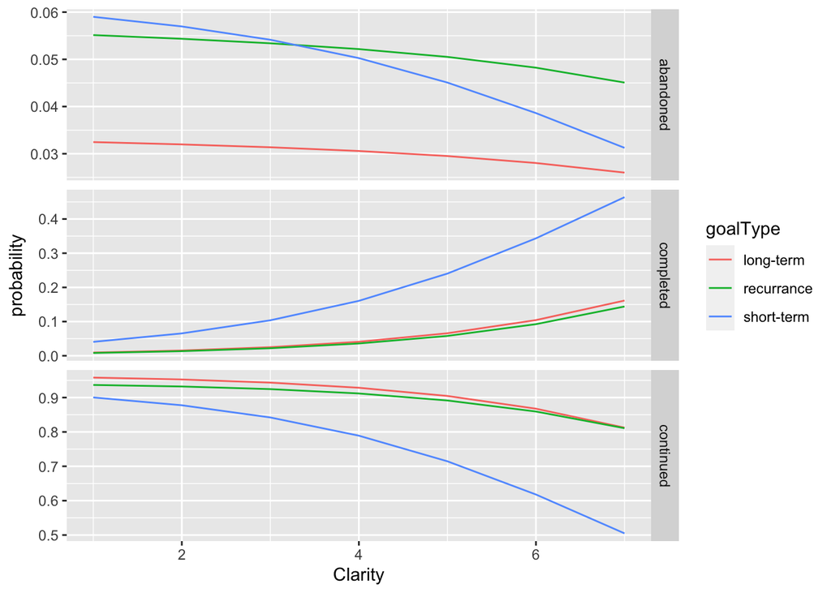

```r
# Generate the predicted probabilities
m3_clarity <- data.frame(goalType = c("short-term", "recurrance", "long-term"), Clarity = rep(c(1:7), 3), final_time = "F3", progress_base = mean(merged_4f_base_clean$progress_base), Value = mean(merged_4f_base_clean$Value))

# generate the pp dataframe
m3_pp <- cbind(m3_clarity, predict(m3, newdata = m3_clarity, type = "probs", se = TRUE))

# transform to long format and plot the probability across goal types
m3_pp %>%
  gather(continued: completed, key = "final_status", value = "probability") %>%
  ggplot(aes(x = Clarity, y = probability, colour = goalType)) +
  geom_line() +
  facet_grid(final_status ~ ., scales = "free")
```

2. The predicted probability of value at F3 while holding the baseline progress and clarity at their mean

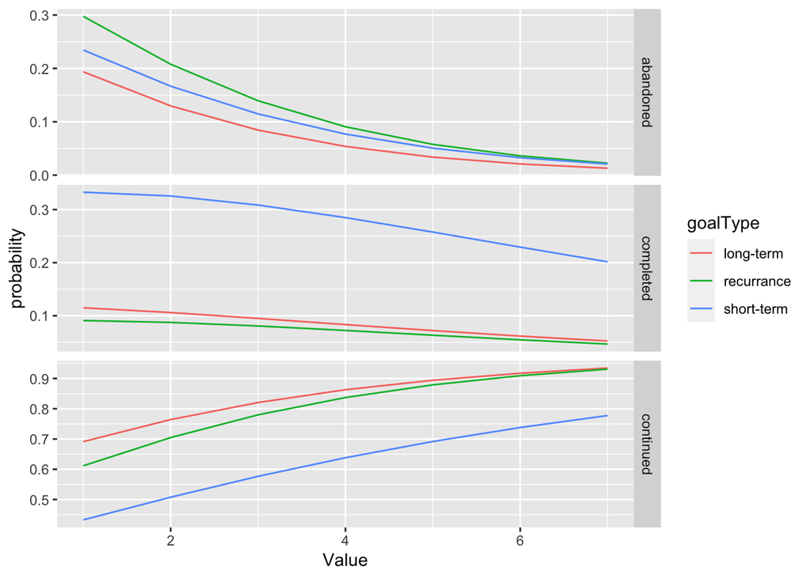

```r
# Generate the predicted probabilities
m3_value <- data.frame(goalType = c("short-term", "recurrance", "long-term"), Value = rep(c(1:7), 3), final_time = "F3", progress_base = mean(merged_4f_base_clean$progress_base), Clarity = mean(merged_4f_base_clean$Clarity))

# generate the pp dataframe
m3_pp <- cbind(m3_value, predict(m3, newdata = m3_value, type = "probs", se = TRUE))

# transform to long format and plot the probability across goal types
m3_pp %>%
  gather(continued: completed, key = "final_status", value = "probability") %>%
  ggplot(aes(x = Value, y = probability, colour = goalType)) +
  geom_line() +
  facet_grid(final_status ~ ., scales = "free")
```

Putting these two plots together, Clarity mostly affect whether people completed the goals and Value mostly affect whehter people continue to pursuit or abandon their goals when they don’t complete them on time.

Goodness to fit

```r
chisq.test(merged_4f_base_clean$status_final,predict(m3), simulate.p.value = TRUE)
```

```
##
##  Pearson's Chi-squared test with simulated p-value (based on 2000
##  replicates)
##
## data:  merged_4f_base_clean$status_final and predict(m3)
## X-squared = 348.86, df = NA, p-value = 0.0004998
```

classification table

```r
classDF <- data.frame(response = merged_4f_base_clean$status_final, predicted = predict(m3))
xtabs(~ predicted + response, data = classDF)
```

```
##            response
## predicted   continued abandoned completed
##   continued       389        22        54
##   abandoned         0        18        10
##   completed         5        28        80
```

The model doesn’t predict the abandoned or completed goals very well, probabily because of the lack of cases under these categories.

### model 8 (Attainability + Value from the 6 factor model)

A summary of the model

```r
summary(m8)
```

```
## Call:
## multinom(formula = status_final ~ goalType + final_time + scale(progress_base) +
##     scale(Attainability) + scale(Value), data = merged_6f_base_clean)
##
## Coefficients:
##           (Intercept) goalTypelong-term goalTypeshort-term final_timeF1
## abandoned   -2.925910       -0.54713923           0.235449     14.87475
## completed   -2.659276        0.09567027           1.638649     14.51052
##           final_timeF2 scale(progress_base) scale(Attainability) scale(Value)
## abandoned     4.296826           -0.3741991           -0.1277146  -0.40838069
## completed     3.983127           -0.0661968            0.3571459  -0.00439024
##
## Std. Errors:
##           (Intercept) goalTypelong-term goalTypeshort-term final_timeF1
## abandoned   0.2899399         0.4544452          0.4024308     79.80183
## completed   0.2609438         0.3973791          0.3257144     79.80154
##           final_timeF2 scale(progress_base) scale(Attainability) scale(Value)
## abandoned    0.5526547            0.1904732            0.1765310    0.1640790
## completed    0.5150871            0.1459076            0.1509334    0.1397128
##
## Residual Deviance: 643.5651
## AIC: 675.5651
```

use a 2-tailed z test to look at the p value of each level of IV

```r
m8_z <- summary(m8)$coefficients/summary(m8)$standard.errors
m8_p <- (1 - pnorm(abs(m8_z), 0, 1)) * 2

m8_p %>%
  kable(format = "html", escape = F) %>%
  kable_styling(bootstrap_options = c("striped", "hover", "condensed"), full_width = F,position = "center")
```

|  | (Intercept) | goalTypelong-term | goalTypeshort-term | final_timeF1 | final_timeF2 | scale(progress_base) | scale(Attainability) | scale(Value) |
| --- | --- | --- | --- | --- | --- | --- | --- | --- |
| abandoned | 0 | 0.2286005 | 0.5585026 | 0.8521341 | 0 | 0.0494633 | 0.4693920 | 0.0128129 |
| completed | 0 | 0.8097464 | 0.0000005 | 0.8557141 | 0 | 0.6500520 | 0.0179694 | 0.9749319 |

Transform the coefficients to odds ratio

```r
exp(coef(m8)) %>%
  kable(format = "html", escape = F) %>%
  kable_styling(bootstrap_options = c("striped", "hover", "condensed"), full_width = F,position = "center")
```

|  | (Intercept) | goalTypelong-term | goalTypeshort-term | final_timeF1 | final_timeF2 | scale(progress_base) | scale(Attainability) | scale(Value) |
| --- | --- | --- | --- | --- | --- | --- | --- | --- |
| abandoned | 0.0536159 | 0.5786027 | 1.265477 | 2884191 | 73.46622 | 0.6878399 | 0.8801045 | 0.6647258 |
| completed | 0.0699989 | 1.1003962 | 5.148211 | 2003735 | 53.68463 | 0.9359467 | 1.4292443 | 0.9956194 |

### Compare the 2 final models:

```r
anova(m3,m8)
```

```
##                                                                                Model
## 1       goalType + final_time + scale(progress_base) + scale(Clarity) + scale(Value)
## 2 goalType + final_time + scale(progress_base) + scale(Attainability) + scale(Value)
##   Resid. df Resid. Dev   Test    Df  LR stat. Pr(Chi)
## 1      1196   644.2143           NA        NA      NA
## 2      1196   643.5651 1 vs 2     0 0.6491991       0
```

#### check the prediction of the model:

1. The predicted probability of attainability at F3 while holding the baseline progress and value at their mean

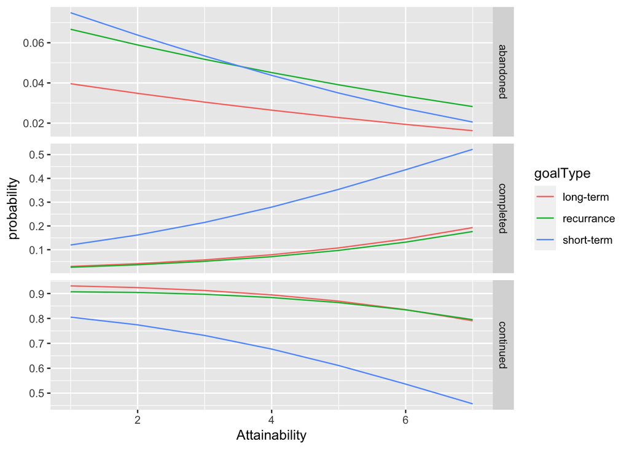

```r
# Generate the predicted probabilities
m8_attainability <- data.frame(goalType = c("short-term", "recurrance", "long-term"), Attainability = rep(c(1:7), 3), final_time = "F3", progress_base = mean(merged_6f_base_clean$progress_base), Value = mean(merged_6f_base_clean$Value))

# generate the pp dataframe
m8_pp_attain <- cbind(m8_attainability, predict(m8, newdata = m8_attainability, type = "probs", se = TRUE))

# transform to long format and plot the probability across goal types
m8_pp_attain %>%
  gather(continued: completed, key = "final_status", value = "probability") %>%
  ggplot(aes(x = Attainability, y = probability, colour = goalType)) +
  geom_line() +
  facet_grid(final_status ~ ., scales = "free")
```

```r
#write.csv(m8, here("TimeSeries", "Outputs", "m8.csv"), row.names = F)
write.csv(m8_attainability, here("TimeSeries", "Outputs", "m8_attainability.csv"), row.names = F)
write.csv(m8_pp_attain, here("TimeSeries", "Outputs", "m8_pp_attain.csv"), row.names = F)
```

2. The predicted probability of value at F3 while holding the baseline progress and attainability at their mean

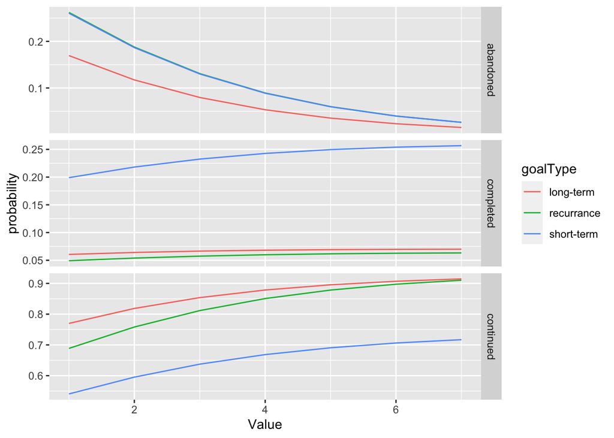

```r
# Generate the predicted probabilities
m8_value <- data.frame(goalType = c("short-term", "recurrance", "long-term"), Value = rep(c(1:7), 3), final_time = "F3", progress_base = mean(merged_6f_base_clean$progress_base), Attainability = mean(merged_6f_base_clean$Attainability))

# generate the pp dataframe
m8_pp_value <- cbind(m8_value, predict(m8, newdata = m8_value, type = "probs", se = TRUE))

# transform to long format and plot the probability across goal types
m8_pp_value %>%
  gather(continued: completed, key = "final_status", value = "probability") %>%
  ggplot(aes(x = Value, y = probability, colour = goalType)) +
  geom_line() +
  facet_grid(final_status ~ ., scales = "free")
```

```r
write.csv(m8_value, here("TimeSeries", "Outputs", "m8_value.csv"), row.names = F)
write.csv(m8_pp_value, here("TimeSeries", "Outputs", "m8_pp_value.csv"), row.names = F)
```

Goodness to fit

```r
chisq.test(merged_4f_base_clean$status_final,predict(m8), simulate.p.value = TRUE)
```

```
##
##  Pearson's Chi-squared test with simulated p-value (based on 2000
##  replicates)
##
## data:  merged_4f_base_clean$status_final and predict(m8)
## X-squared = 343.5, df = NA, p-value = 0.0004998
```

classification table

```r
classDF <- data.frame(response = merged_4f_base_clean$status_final, predicted = predict(m8))
xtabs(~ predicted + response, data = classDF)
```

```
##            response
## predicted   continued abandoned completed
##   continued       389        22        54
##   abandoned         0        17        10
##   completed         5        29        80
```

The results are very similar to model 3.

# Multinormial logistic regression models among short-term goals

The uneven cases across groups always hinder the model performance for both the mlm models and the multinomial model. Therefore, it may be interesting to focus only on the short-term goals which has a slightly more even numbers of cases across the final status. These are the goals that people anticipate to coomplete within the 3-month, so it would be interesting to see if any baseline factors predict whether people abandoned the goals or continue to pursuit the goals if they didn’t complete them on time.

## Descriptives

```r
# subset the datasets for short-term goals
merged_4f_base_st <- merged_4f_base_clean %>% filter(goalType == "short-term")
merged_6f_base_st <- merged_6f_base_clean %>% filter(goalType == "short-term")
```

a count table

```r
tabyl(merged_4f_base_st, final_time, status_final)
```

```
##  final_time continued abandoned completed
##          F3        78         8        30
##          F1         0         5        29
##          F2         2        10        31
```

The status “continued” occurs almost exclusively at F3.

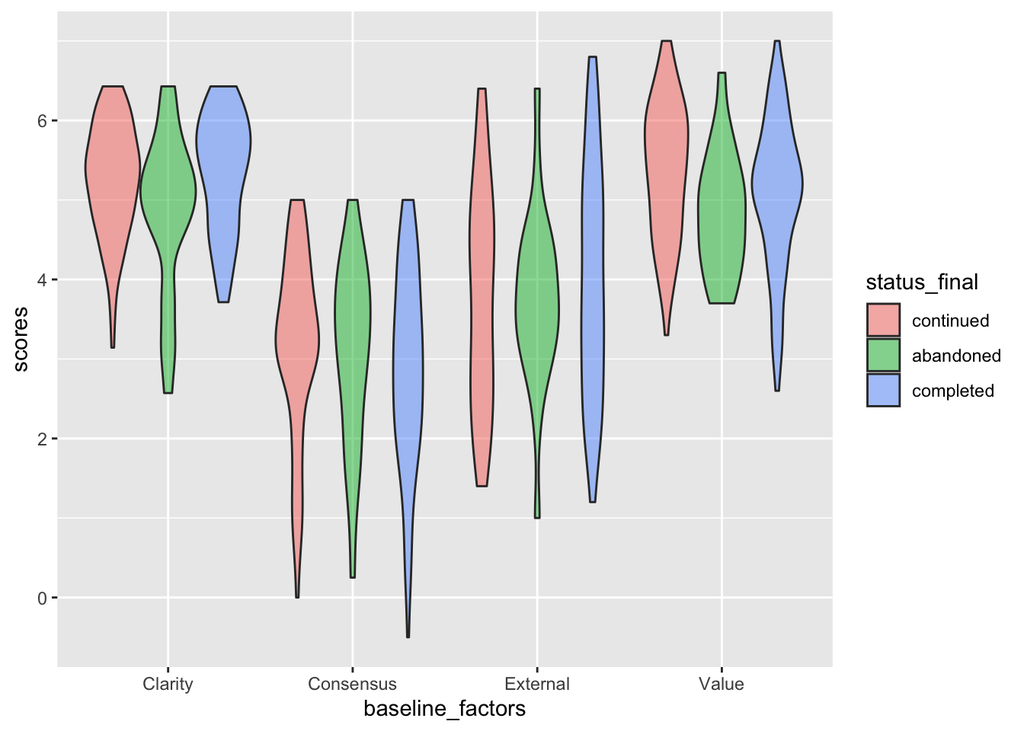

```r
merged_4f_base_st %>%
  gather(Value : Consensus, key = "baseline_factors", value = "scores") %>%
  ggplot(aes(fill = status_final, y = scores, x = baseline_factors)) +
  geom_violin(position="dodge", alpha=0.5, outlier.colour="transparent")
```

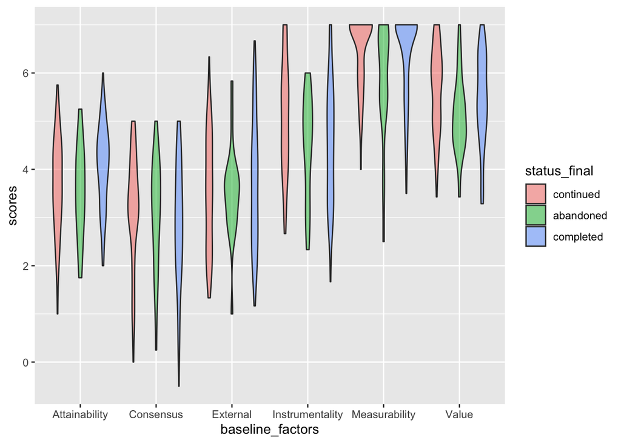

```r
merged_6f_base_st %>%
  gather(Value : Instrumentality, key = "baseline_factors", value = "scores") %>%
  ggplot(aes(fill = status_final, y = scores, x = baseline_factors)) +
  geom_violin(position="dodge", alpha=0.5, outlier.colour="transparent")
```

The violin plots are similar to the ones that include all the goals. The 6-factor model plot shows slightly more variations across the final statuses.

## Model s1 (no baseline factor scores)

For all following models, the completed goal is the reference group.

```r
# set the reference group:
merged_4f_base_st$status_final <- relevel(merged_4f_base_st$status_final, ref = "completed")
merged_6f_base_st$status_final <- relevel(merged_6f_base_st$status_final, ref = "completed")
```

```r
# create a model
s1 <- multinom(status_final ~ final_time + progress_base, data = merged_4f_base_st)
summary(s1)
```

```
## Call:
## multinom(formula = status_final ~ final_time + progress_base,
##     data = merged_4f_base_st)
##
## Coefficients:
##           (Intercept) final_timeF1 final_timeF2 progress_base
## continued    0.928628  -14.9096666   -3.6989892    0.00999045
## abandoned   -1.009141   -0.1687436    0.2148636   -0.13914243
##
## Std. Errors:
##           (Intercept) final_timeF1 final_timeF2 progress_base
## continued   0.2967107  196.9326117    0.7608979    0.07625405
## abandoned   0.4451121    0.6548543    0.5438303    0.09637181
##
## Residual Deviance: 273.4826
## AIC: 289.4826
```

```r
s1_z <- summary(s1)$coefficients/summary(s1)$standard.errors
s1_p <- (1 - pnorm(abs(s1_z), 0, 1)) * 2
s1_p
```

```
##           (Intercept) final_timeF1 final_timeF2 progress_base
## continued 0.001749598    0.9396502 1.165892e-06     0.8957632
## abandoned 0.023380344    0.7966530 6.927742e-01     0.1487929
```

The baseline progress is not a significant predictor, which is different from those including all the goals.

## Model s2 (only include the final timepoint)

```r
# create a model
s2 <- multinom(status_final ~ final_time, data = merged_4f_base_st)
summary(s2)
```

```
## Call:
## multinom(formula = status_final ~ final_time, data = merged_4f_base_st)
##
## Coefficients:
##           (Intercept) final_timeF1 final_timeF2
## continued   0.9555294  -12.6436949   -3.6965993
## abandoned  -1.3217233   -0.4360581    0.1903067
##
## Std. Errors:
##           (Intercept) final_timeF1 final_timeF2
## continued   0.2148355   64.1006075    0.7606049
## abandoned   0.3979090    0.6267402    0.5390633
##
## Residual Deviance: 275.9706
## AIC: 287.9706
```

## comparison between s1 & s2

```r
anova(s1, s2)
```

```
##                        Model Resid. df Resid. Dev   Test    Df LR stat.
## 1                 final_time       380   275.9706           NA       NA
## 2 final_time + progress_base       378   273.4826 1 vs 2     2 2.488011
##     Pr(Chi)
## 1        NA
## 2 0.2882273
```

including the baseline progress does not improve the model fit.

## Model s2.1 (only include the baseline progress)

```r
# create a model
s2.1 <- multinom(status_final ~ progress_base, data = merged_4f_base_st)
summary(s2.1)
```

```
## Call:
## multinom(formula = status_final ~ progress_base, data = merged_4f_base_st)
##
## Coefficients:
##           (Intercept) progress_base
## continued   0.1541754   -0.08856917
## abandoned  -0.9255128   -0.15491667
##
## Std. Errors:
##           (Intercept) progress_base
## continued   0.2297107    0.05596212
## abandoned   0.3310027    0.09325856
##
## Residual Deviance: 371.7483
## AIC: 379.7483
```

```r
s2.1_z <- summary(s2.1)$coefficients/summary(s2.1)$standard.errors
s2.1_p <- (1 - pnorm(abs(s2.1_z), 0, 1)) * 2
s2.1_p
```

```
##           (Intercept) progress_base
## continued 0.502111011    0.11349830
## abandoned 0.005172525    0.09668287
```

The baseline progress doesn’t predict the fianl status at F3 either.

## Models with the baseline 4-factor scores

### Model s3 (includes final_time + clarity)

```r
s3 <- multinom(status_final ~ final_time + Clarity, data = merged_4f_base_st)
summary(s3)
```

```
## Call:
## multinom(formula = status_final ~ final_time + Clarity, data = merged_4f_base_st)
##
## Coefficients:
##           (Intercept) final_timeF1 final_timeF2    Clarity
## continued    2.112231  -13.7740184  -3.73830519 -0.2175857
## abandoned    2.354259   -0.4175359   0.03651592 -0.7093515
##
## Std. Errors:
##           (Intercept) final_timeF1 final_timeF2   Clarity
## continued    1.495361  113.6953852    0.7647039 0.2772474
## abandoned    1.551193    0.6436125    0.5569266 0.2942826
##
## Residual Deviance: 270.0517
## AIC: 286.0517
```

```r
anova(s2,s3)
```

```
##                  Model Resid. df Resid. Dev   Test    Df LR stat.    Pr(Chi)
## 1           final_time       380   275.9706           NA       NA         NA
## 2 final_time + Clarity       378   270.0517 1 vs 2     2  5.91895 0.05184613
```

The anova test showed that the chi-square is 5.9 and the p = .05, so including the baseline clarity factor score improves (marginally) the model fit.

```r
s3_z <- summary(s3)$coefficients/summary(s3)$standard.errors
s3_p <- (1 - pnorm(abs(s3_z), 0, 1)) * 2
s3_p
```

```
##           (Intercept) final_timeF1 final_timeF2    Clarity
## continued   0.1577961    0.9035735 1.015733e-06 0.43256672
## abandoned   0.1290879    0.5165077 9.477227e-01 0.01593314
```

### Model s4 (include final time, clarity, value)

```r
s4 <- multinom(status_final ~ final_time + Clarity + Value, data = merged_4f_base_st)
summary(s4)
```

```
## Call:
## multinom(formula = status_final ~ final_time + Clarity + Value,
##     data = merged_4f_base_st)
##
## Coefficients:
##           (Intercept) final_timeF1 final_timeF2    Clarity      Value
## continued   0.7142988   -13.816850 -3.695516608 -0.2313118  0.2781922
## abandoned   3.3780097    -0.489634 -0.000910378 -0.6843964 -0.2257011
##
## Std. Errors:
##           (Intercept) final_timeF1 final_timeF2   Clarity     Value
## continued    1.893733  120.3471064    0.7659266 0.2806635 0.2352158
## abandoned    1.997857    0.6527648    0.5597934 0.2962060 0.2730764
##
## Residual Deviance: 267.295
## AIC: 287.295
```

```r
anova(s3,s4)
```

```
##                          Model Resid. df Resid. Dev   Test    Df LR stat.
## 1         final_time + Clarity       378   270.0517           NA       NA
## 2 final_time + Clarity + Value       376   267.2950 1 vs 2     2 2.756698
##     Pr(Chi)
## 1        NA
## 2 0.2519942
```

The anova test showed that the chi-square is 2.76 and the p = .25, so including the baseline value factor score doesn’t improve the model fit.

### Model s3.1 (includes baseline_progross as a covariate)

```r
s3.1 <- multinom(status_final ~ final_time + Clarity + progress_base, data = merged_4f_base_st)
summary(s3.1)
```

```
## Call:
## multinom(formula = status_final ~ final_time + Clarity + progress_base,
##     data = merged_4f_base_st)
##
## Coefficients:
##           (Intercept) final_timeF1 final_timeF2    Clarity progress_base
## continued    1.990639  -14.7289823  -3.73577962 -0.2022775    0.01477048
## abandoned    2.514890   -0.2110766   0.03801934 -0.6870469   -0.11804094
##
## Std. Errors:
##           (Intercept) final_timeF1 final_timeF2   Clarity progress_base
## continued    1.511887  180.5127986    0.7642922 0.2777708    0.07624360
## abandoned    1.600514    0.6650912    0.5612695 0.3025823    0.09755564
##
## Residual Deviance: 268.2511
## AIC: 288.2511
```

```r
s3.1_z <- summary(s3.1)$coefficients/summary(s3.1)$standard.errors
s3.1_p <- (1 - pnorm(abs(s3.1_z), 0, 1)) * 2
s3.1_p
```

```
##           (Intercept) final_timeF1 final_timeF2    Clarity progress_base
## continued   0.1879530    0.9349686 0.0000010192 0.46648065     0.8463893
## abandoned   0.1161126    0.7509667 0.9459941008 0.02317047     0.2262844
```

## Models with the 6-factor scores

### Model s5 (includes final_time + Attainability)

```r
s5 <- multinom(status_final ~ final_time + Attainability, data = merged_6f_base_st)
summary(s5)
```

```
## Call:
## multinom(formula = status_final ~ final_time + Attainability,
##     data = merged_6f_base_st)
##
## Coefficients:
##           (Intercept) final_timeF1 final_timeF2 Attainability
## continued    2.630737  -15.2355083   -3.7326856    -0.4348274
## abandoned    1.004615   -0.3040687    0.1498667    -0.6163340
##
## Std. Errors:
##           (Intercept) final_timeF1 final_timeF2 Attainability
## continued   0.9162252  246.0180048    0.7657416     0.2267777
## abandoned   1.0526842    0.6447416    0.5521427     0.2665071
##
## Residual Deviance: 268.6082
## AIC: 284.6082
```

```r
anova(s2,s5)
```

```
##                        Model Resid. df Resid. Dev   Test    Df LR stat.
## 1                 final_time       380   275.9706           NA       NA
## 2 final_time + Attainability       378   268.6082 1 vs 2     2 7.362406
##      Pr(Chi)
## 1         NA
## 2 0.02519265
```

The anova test showed that the chi-square is 7.36 and the p = .03, so including the baseline attainability factor score improves the model fit.

```r
s5_z <- summary(s5)$coefficients/summary(s5)$standard.errors
s5_p <- (1 - pnorm(abs(s5_z), 0, 1)) * 2
s5_p
```

```
##           (Intercept) final_timeF1 final_timeF2 Attainability
## continued 0.004088165    0.9506198 1.090278e-06    0.05518495
## abandoned 0.339913245    0.6372028 7.860623e-01    0.02074265
```

### Model s6 (includes final_time + Attainability + Value)

```r
s6 <- multinom(status_final ~ final_time + Attainability + Value, data = merged_6f_base_st)
summary(s6)
```

```
## Call:
## multinom(formula = status_final ~ final_time + Attainability +
##     Value, data = merged_6f_base_st)
##
## Coefficients:
##           (Intercept) final_timeF1 final_timeF2 Attainability      Value
## continued    1.900594  -15.1910822  -3.71781837    -0.4385818  0.1326578
## abandoned    3.108417   -0.3982589   0.08641193    -0.6134811 -0.3915962
##
## Std. Errors:
##           (Intercept) final_timeF1 final_timeF2 Attainability     Value
## continued    1.550488 4.064849e-06    0.7668469     0.2271405 0.2252560
## abandoned    1.797944 6.535094e-01    0.5592663     0.2660679 0.2664084
##
## Residual Deviance: 265.3908
## AIC: 285.3908
```

```r
anova(s5,s6)
```

```
##                                Model Resid. df Resid. Dev   Test    Df LR stat.
## 1         final_time + Attainability       378   268.6082           NA       NA
## 2 final_time + Attainability + Value       376   265.3908 1 vs 2     2 3.217396
##    Pr(Chi)
## 1       NA
## 2 0.200148
```

The anova test showed that the chi-square is 3.21 and the p = .2, so including the baseline value factor score doesn’t improve the model fit. I also tried adding the rest of the factor scores and none of these scores improve the model fit.

## Interpret the final models

### The final model including clarity from the 4-factor model

Adding the baseline progress as the covariate to the model

```r
s3.1 <- multinom(status_final ~ final_time + Clarity + progress_base, data = merged_4f_base_st)
summary(s3.1)
```

```
## Call:
## multinom(formula = status_final ~ final_time + Clarity + progress_base,
##     data = merged_4f_base_st)
##
## Coefficients:
##           (Intercept) final_timeF1 final_timeF2    Clarity progress_base
## continued    1.990639  -14.7289823  -3.73577962 -0.2022775    0.01477048
## abandoned    2.514890   -0.2110766   0.03801934 -0.6870469   -0.11804094
##
## Std. Errors:
##           (Intercept) final_timeF1 final_timeF2   Clarity progress_base
## continued    1.511887  180.5127986    0.7642922 0.2777708    0.07624360
## abandoned    1.600514    0.6650912    0.5612695 0.3025823    0.09755564
##
## Residual Deviance: 268.2511
## AIC: 288.2511
```

use a 2-tailed z test to look at the p value of each level of IV

```r
s3.1_z <- summary(s3.1)$coefficients/summary(s3.1)$standard.errors
s3.1_p <- (1 - pnorm(abs(s3.1_z), 0, 1)) * 2
s3.1_p
```

```
##           (Intercept) final_timeF1 final_timeF2    Clarity progress_base
## continued   0.1879530    0.9349686 0.0000010192 0.46648065     0.8463893
## abandoned   0.1161126    0.7509667 0.9459941008 0.02317047     0.2262844
```

transform the coefficients to odd ratios

```r
exp(coef(s3.1))
```

```
##           (Intercept) final_timeF1 final_timeF2   Clarity progress_base
## continued    7.320212 4.011292e-07   0.02385457 0.8168682     1.0148801
## abandoned   12.365246 8.097120e-01   1.03875132 0.5030594     0.8886597
```

This model shows that after controlling for baseline progress, when increase 1 unit in baseline Clarity factor score, the odds ratio of abandoning the goal versis completing the goal becomes 0.5 times as before.

#### check the prediction of the model

Plot the predicted probabilities of the clarity factor across follow-ups when holding the baseline progress at its mean.

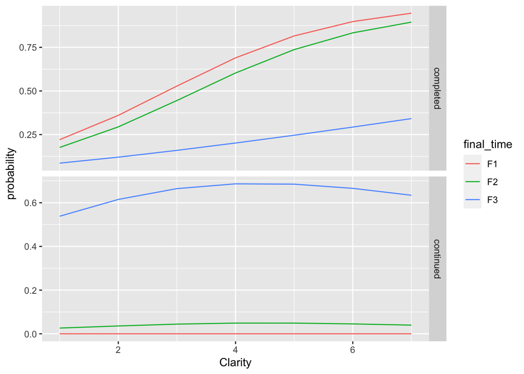

```r
# Generate the predicted probabilities
s3.1_clarity <- data.frame(Clarity = rep(c(1:7), 3), final_time = c("F1","F2","F3"), progress_base = mean(merged_4f_base_st$progress_base))

# generate the pp dataframe
s3.1_pp <- cbind(s3.1_clarity, predict(s3.1, newdata = s3.1_clarity, type = "probs", se = TRUE))

# transform to long format and plot the probability across goal types
s3.1_pp %>%
  gather(continued: completed, key = "final_status", value = "probability") %>%
  ggplot(aes(x = Clarity, y = probability, colour = final_time)) +
  geom_line() +
  facet_grid(final_status ~ ., scales = "free")
```

The main issue of using only the short-term goals in the model is that the model failed to predict abandoned goals (also see the classification table). We have too few cases.Also, from the figure we can see taht the effect of clarity are the strongest for completed goals at F1 & F2. These are the goals that are completed on time or every earlier than the plan.

```r
chisq.test(merged_4f_base_st$status_final,predict(s3.1), simulate.p.value = TRUE)
```

```
##
##  Pearson's Chi-squared test with simulated p-value (based on 2000
##  replicates)
##
## data:  merged_4f_base_st$status_final and predict(s3.1)
## X-squared = 86.537, df = NA, p-value = 0.0004998
```

```r
classDF <- data.frame(response = merged_4f_base_st$status_final, predicted = predict(s3.1))
xtabs(~ predicted + response, data = classDF)
```

```
##            response
## predicted   completed continued abandoned
##   completed        60         2        14
##   continued        30        78         8
##   abandoned         0         0         1
```

The model does a very poor job predicting abandoned goals.

Adding the baseline progress as the covariate to the model

```r
s5.1 <- multinom(status_final ~ final_time + Attainability + progress_base, data = merged_6f_base_st)
summary(s5.1)
```

```
## Call:
## multinom(formula = status_final ~ final_time + Attainability +
##     progress_base, data = merged_6f_base_st)
##
## Coefficients:
##           (Intercept) final_timeF1 final_timeF2 Attainability progress_base
## continued    2.528424  -16.2744801   -3.7316752    -0.4262888    0.02517323
## abandoned    1.029637   -0.1541517    0.1613417    -0.5616693   -0.09827365
##
## Std. Errors:
##           (Intercept) final_timeF1 final_timeF2 Attainability progress_base
## continued   0.9244713 5.669407e-07    0.7655610     0.2278001    0.07654724
## abandoned   1.0628694 6.638214e-01    0.5533977     0.2727451    0.09761266
##
## Residual Deviance: 267.1966
## AIC: 287.1966
```

use a 2-tailed z test to look at the p value of each level of IV

```r
s5.1_z <- summary(s5.1)$coefficients/summary(s5.1)$standard.errors
s5.1_p <- (1 - pnorm(abs(s5.1_z), 0, 1)) * 2
s5.1_p
```

```
##           (Intercept) final_timeF1 final_timeF2 Attainability progress_base
## continued 0.006238126    0.0000000 1.091220e-06    0.06129957     0.7422624
## abandoned 0.332678232    0.8163682 7.706326e-01    0.03946363     0.3140446
```

transform the coefficients to odd ratios

```r
exp(coef(s5.1))
```

```
##           (Intercept) final_timeF1 final_timeF2 Attainability progress_base
## continued    12.53374 8.552304e-08   0.02395268     0.6529277     1.0254928
## abandoned     2.80005 8.571420e-01   1.17508644     0.5702563     0.9064008
```

#### check the prediction of the model

Plot the predicted probabilities of the attainability factor across follow-ups when holding the baseline progress at its mean.

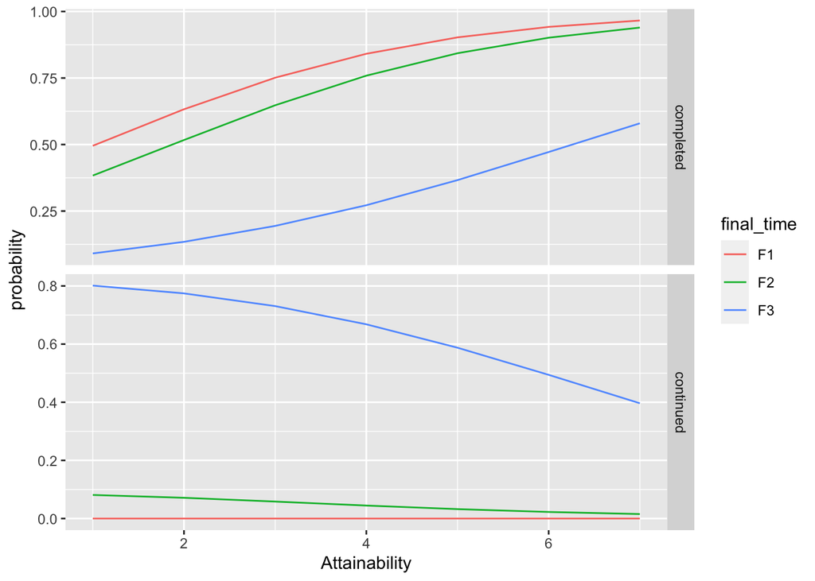

```r
# Generate the predicted probabilities
s5.1_clarity <- data.frame(Attainability = rep(c(1:7), 3), final_time = c("F1","F2","F3"), progress_base = mean(merged_4f_base_st$progress_base))

# generate the pp dataframe
s5.1_pp <- cbind(s5.1_clarity, predict(s5.1, newdata = s5.1_clarity, type = "probs", se = TRUE))

# transform to long format and plot the probability across goal types
s5.1_pp %>%
  gather(continued: completed, key = "final_status", value = "probability") %>%
  ggplot(aes(x = Attainability, y = probability, colour = final_time)) +
  geom_line() +
  facet_grid(final_status ~ ., scales = "free")
```

Compared to the model with Clarity, the probability of the final status at F3 vary more.

```r
chisq.test(merged_6f_base_st$status_final,predict(s5.1), simulate.p.value = TRUE)
```

```
##
##  Pearson's Chi-squared test with simulated p-value (based on 2000
##  replicates)
##
## data:  merged_6f_base_st$status_final and predict(s5.1)
## X-squared = 79.704, df = NA, p-value = 0.0004998
```

```r
classDF <- data.frame(response = merged_6f_base_st$status_final, predicted = predict(s5.1))
xtabs(~ predicted + response, data = classDF)
```

```
##            response
## predicted   completed continued abandoned
##   completed        60         2        15
##   continued        30        78         8
##   abandoned         0         0         0
```

The results from the 6-factor model are very similar to those from the 4-factor model.

### Compare the two final model

```r
anova(s3.1, s5.1)
```

```
##                                        Model Resid. df Resid. Dev   Test    Df
## 1       final_time + Clarity + progress_base       376   268.2511           NA
## 2 final_time + Attainability + progress_base       376   267.1966 1 vs 2     0
##   LR stat. Pr(Chi)
## 1       NA      NA
## 2 1.054461       0
```